# Seeds - Random effect logistic regression

BRUNO LOPES Matheus, MOURDI Elias, SELAMNIA Najib, TRIOMPHE Amaury, YOUSFI Rim

15/04/2024

**Lien vers notre Github** : `https://github.com/azer1230/-BAYES-Projet-1`

# Données étudiées

# Cadre mathématique

## Hypothèses sur nos données

Si $p_i$ est la probabilité de germination sur la plaque $i$, alors supposons que le nombre de graines germées $r_i$ suit une loi binomiale :

$$r_i \sim \text{Binomial}(p_i,n_i)$$

De plus, supposons que le modèle est essentiellement une régression logistique à effets aléatoires, ce qui permet de traiter la surdispersion. Autrement dit :

$$\text{logit}(p_i) = \alpha_0 + \alpha_1x_{1i} + \alpha_2x_{2i} +
\alpha_{12}x_{1i}x_{2i} + b_i \\
\text{où } b_i \sim \mathcal{N}(0,\frac{1}{\tau})$$

avec $x_{1i}$, $x_{2i}$ le type de graine et l’extrait de racine de la $i$-ème plaque, et avec un terme d’interaction $\alpha_{12}x_{1i}x_{2i}$ inclus. $\alpha_0, \alpha_1, \alpha_2, \alpha_{12}, \tau$ ont des priors indépendants “non informatifs” fournis, qui seront supposés comme suit :

$$\alpha_i \sim \mathcal{N}(0, 10^6), \: \text{pour} \: i \in \{0, 1,
2\} \\
\alpha_{12} \sim \mathcal{N}(0, 10^6) \\
\tau \sim \text{gamma}(10^{-3}, 10^{-3})$$

Une dernière hypothèse que nous ferons également est que les $r_i$ sont indépendants.

## Lois conditionnelles

Comme nous allons appliquer Hastings-within-Gibbs, nous devrons déterminer les lois conditionnelles de tous les paramètres de l’expression de $logit(p_i)$, c’est-à-dire que nous devrons obtenir toutes les lois à posteriori. Pour $\alpha_0$, nous aurons :

$$\pi(\alpha_0|\alpha_1, \alpha_{12}, \alpha_2, r, b, \tau) \propto
\pi(\alpha_1, \alpha_{12}, \alpha_2, r, b, \tau|\alpha_0)\pi(\alpha_0)$$

Dans le contexte de H-W-Gibbs, comme nous allons mettre à jour les paramètres séparément en considérant les autres comme des valeurs fixes, nous aurons :

$$\pi(\alpha_0|\alpha_1, \alpha_{12}, \alpha_2, r, b, \tau) \propto
\pi(r|\alpha_0,\alpha_1, \alpha_{12}, \alpha_2, b, \tau)\pi(\alpha_0)\\
= \pi(\alpha_0)\prod_{i=1}^N\pi(r_i|\alpha_0,\alpha_1, \alpha_{12},
\alpha_2, i,b, \tau)\\ = \pi(\alpha_0)\prod_{i=1}^Np_i^{r_i}(1-p)^{n_i -
r_i}$$

Comme tous les $\alpha$ suivent la même loi a priori, nous aurons des expressions similaires pour $\alpha_1, \alpha_{12}$ et $\alpha_2$. Pour $\tau$, comme $\tau$ dépend de $b$ qui suit une loi normale, qui dans ce cas est conjuguée par la loi gamma (loi a priori de $\tau$), nous pouvons obtenir directement sa loi a posteriori :

$$\pi(\tau|\alpha_0, \alpha_{1}, \alpha_{12},\alpha_2, i , b, r) \sim
gamma(10^{-3} + \frac{N}{2}, 10^{-3} + \frac{\sum_{i=1}^Nb_i^2}{2})$$

Une fois $\tau$ mis à jour dans l’algorithme, nous pourrons mettre à jour chaque $b_i$, pour $i \in \{1, ..., N\}$, où chacun aura la loi à posteriori suivante :

$$\pi(b_i| \alpha_0, \alpha_{1}, \alpha_{12},\alpha_2, i , r_i, \tau)
\propto \pi( \alpha_0, \alpha_{1}, \alpha_{12},\alpha_2, i , r_i, \tau|
b_i)\pi(b_i)$$

En considérant que $\alpha_0, \alpha_{1}, \alpha_{12},\alpha_2, i, \tau$ sont des paramètres déjà fixes et que $b_i \sim N(0,\frac{1}{\tau})$, nous pouvons écrire :

$$\pi(b_i| \alpha_0, \alpha_{1}, \alpha_{12},\alpha_2, i , r_i, \tau)
\propto \pi(r_i|\alpha_0, \alpha_{1}, \alpha_{12},\alpha_2, i , \tau,
b_i)\exp(-\frac{b_i^2\tau}{2}) \\
=p_i^{r_i}(1-p_i)^{n_i-r_i}\exp{(-\frac{b_i^2\tau}{2})}$$

Maintenant, ayant toutes les lois conditionnelles, nous pouvons appliquer notre algorithme Hastings-within-Gibbs.

# Résultats de l’implémentation algorithmique

On rend également compte des résultats des chaînes de Markov générées (à gauche), ainsi que de leurs distributions (à droite) dans ls graphiques ci-dessous:

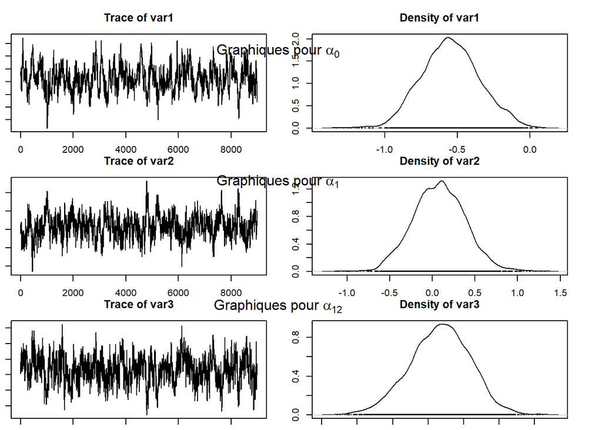

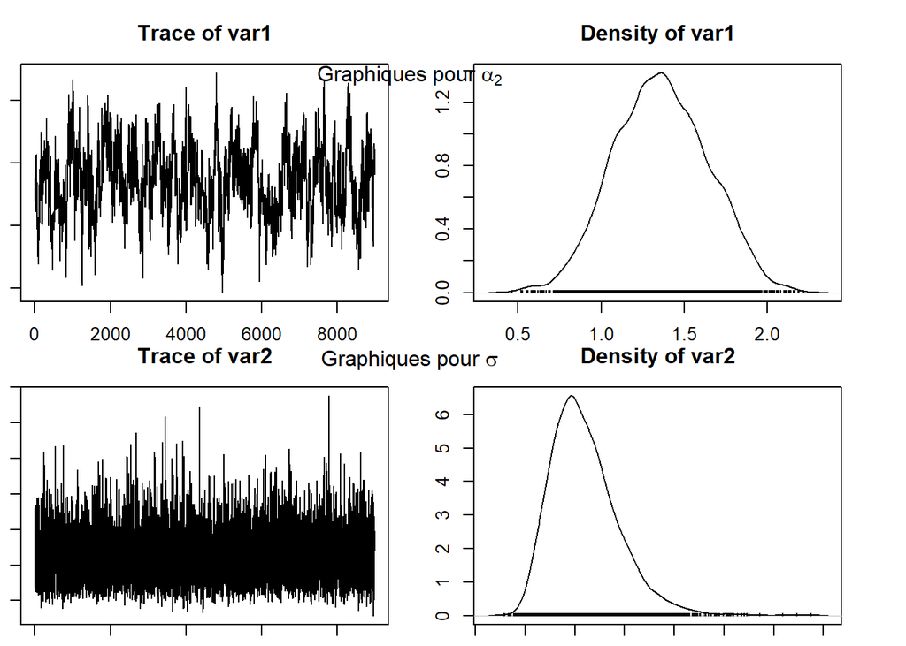

# Interprétation des résultats

On va maintenant essayer de voir l’impact de $x_1$ et $x_2$ sur $logit(p)$. Pour cela, on réutilise les moyennes des variables aléatoires que l’on a calculé avant.

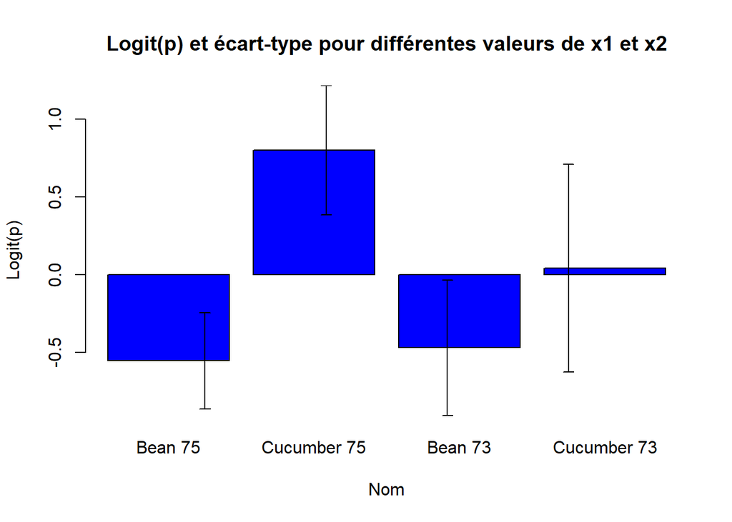

On voit que le cucumber de l’aegyptiao 75 est celle qui a le plus de chance de germer. C’est notamment plus élévé que pour l’autre type de graine l’aegyptiao 73 avec la même racine (cucumber). Pour la racine bean, on a mons de chance de germer que pour cucumber et il a très peu de différences selon le type de graine (aegyptiao 75 ou aegyptiao 73).